# Telling a Data Story

Katherine Muller

2025-11-26

This document corresponds to the lecture “Telling a Data Story” for the 2026 course in Bayesian data analysis from the Sustainability Lake Chad project.

## Using statistical models to describe data

### Dataset: “heights”

- Height data from the US Bureau of Labor Statistics National Longitudinal Survey, 2012
- Imported from the *modelr* package
- Includes various demographic data for US adults

```r
# load data to environment
data(heights)
summary(heights)
```

```
##      income             height         weight           age
##  Min.   :     0.0   Min.   :52.0   Min.   : 76.0   Min.   :47.00
##  1st Qu.:   165.5   1st Qu.:64.0   1st Qu.:157.0   1st Qu.:49.00
##  Median : 29589.5   Median :67.0   Median :184.0   Median :51.00
##  Mean   : 41203.9   Mean   :67.1   Mean   :188.3   Mean   :51.33
##  3rd Qu.: 55000.0   3rd Qu.:70.0   3rd Qu.:212.0   3rd Qu.:53.00
##  Max.   :343830.0   Max.   :84.0   Max.   :524.0   Max.   :56.00
##                                    NA's   :95
##       marital         sex         education          afqt
##  single   :1124   male  :3402   Min.   : 1.00   Min.   :  0.00
##  married  :3806   female:3604   1st Qu.:12.00   1st Qu.: 15.12
##  separated: 366                 Median :12.00   Median : 36.76
##  divorced :1549                 Mean   :13.22   Mean   : 41.21
##  widowed  : 161                 3rd Qu.:15.00   3rd Qu.: 65.24
##                                 Max.   :20.00   Max.   :100.00
##                                 NA's   :10      NA's   :262
```

## Using statistical models to describe data

We can plot the distribution of height in this dataset.

When we visualize data distribution, we typically look at **probability density** over the range of the data. The plots below illustrate what we mean by probability density.

- The plot on the left splits the height data into one-inch bins and counts the number of individuals in each bin.
- The plot on the right does the same thing, then divides by the total number of individuals so each bin is a proportion and all bins sum to one. The empirical probability density, drawn with the geom_density function, essentially does the same thing, but with bins that are so small they make a smooth line.

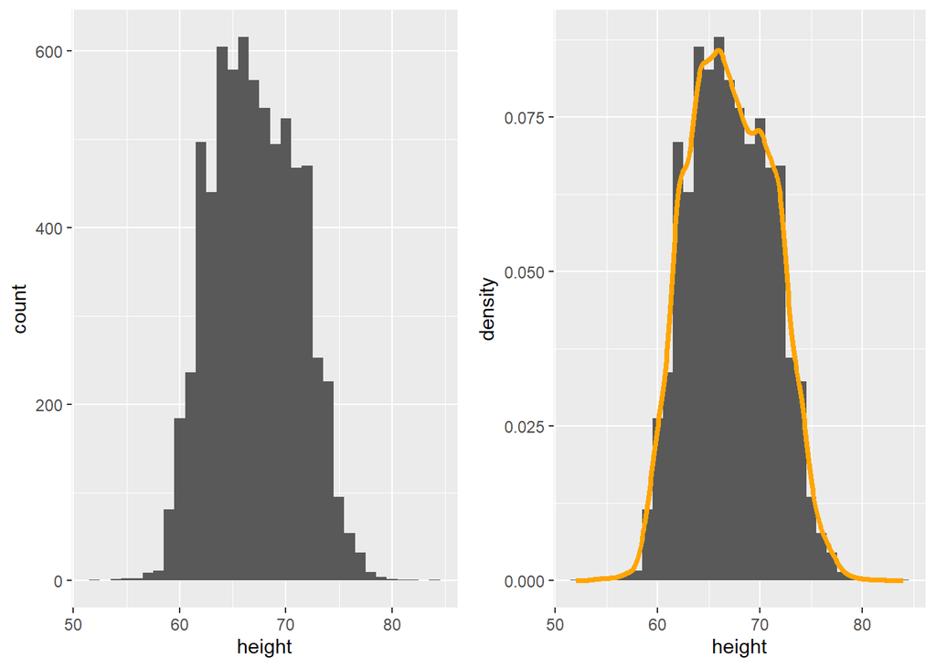

```r
p1 <- ggplot(heights) + geom_histogram(aes(x = height, y = stat(count)),binwidth=1)
p2a <-ggplot(heights) + geom_histogram(aes(x = height, y = stat(density)),binwidth=1)
p2 <-  p2a +  geom_density(aes(x=height), color = "orange", lwd=1.3)
cowplot::plot_grid(p1, p2)
```

## Descriptive models:

This distribution can be described using a gaussian probability density function.

### Model 1: One mean and one variance

$$\begin{align*}
&\text{height} \sim \mathcal{N}(\mu, \sigma) \\
&\mu \approx \text{mean(height)}, \quad \sigma \approx
\text{sd(height)}
\end{align*}$$

### Model 2: Mixture with means and variances for men and women

$$\begin{align*}
\text{height} &\sim \phi_W\mathcal{N}(\mu_W, \sigma_W)
+ (1-\phi_W)\mathcal{N}(\mu_M, \sigma_M)\\
&\mu_W \approx \text{mean}(\text{height}_W), \quad \mu_M \approx
\text{mean}(\text{height}_M) \\
&\sigma_W \approx \text{sd}(\text{height}_W), \quad \sigma_M \approx
\text{sd}(\text{height}_M) \\
&\phi_W \approx N_W / N_{obs}
\end{align*}$$

```r
m1pars <- heights %>% summarize(mean = mean(height, na.rm=TRUE),
                                sd = sd(height, na.rm= TRUE))
m2pars <- heights %>% group_by(sex) %>% # performs calculations separately on each group
                      summarize(mean = mean(height, na.rm=TRUE), # summary statistics
                                 sd = sd(height, na.rm= TRUE),
                                N = n()) %>% ungroup() %>% # need to ungroup to get the sum of men and women
                      mutate(phi = N/sum(N) ) %>%
                      split(.$sex) ## splits male and female rows into a named list.

# the height range in the data spans 52-84 inches. I'm going to plot a range that's slightly wider.
heightspan <- seq(50,90,by=0.2)

## Use dnorm to calculate the theoretical probability density for a
# gaussian distribution with specified mean, variance, and data values. This is the same
# as plugging everything into the gaussian probability density function
model1 <- dnorm(x = heightspan, mean = m1pars$mean, sd = m1pars$sd)
model2 <- m2pars$female$phi * dnorm(x = heightspan, mean = m2pars$female$mean, sd = m2pars$female$sd) +
      m2pars$male$phi * dnorm(x = heightspan, mean = m2pars$male$mean, sd = m2pars$male$sd)
```

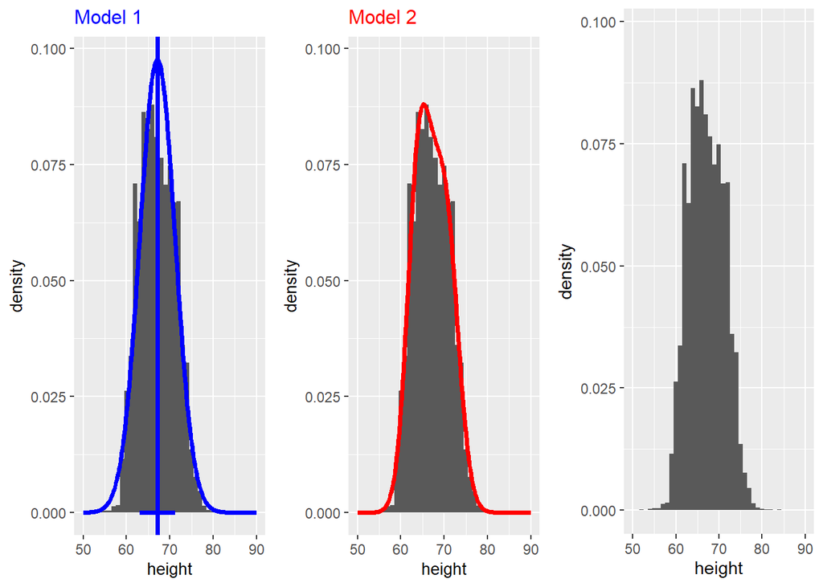

```r
## when combining data objects on the same plot, you have to call the
# data in the plot component, rather than the ggplot environment.
ymax <- max(model1, model2, na.rm=TRUE) ## get the maximum density to set y axis limits

## base histogram
p0 <- ggplot() + geom_histogram(data = heights,aes(x = height, y = stat(density)),binwidth=1)+
  coord_cartesian(ylim = c(0, ymax),xlim = c(50,90))  # axis limits

## add mean and sd
p0a <- p0 +  geom_vline(xintercept = m1pars$mean, color = "blue",lwd=1.3) +
  geom_segment(data = m1pars, aes(x = mean - sd, xend = mean + sd,y=0, yend = 0), color = "blue", lwd = 1.3) + labs(title = "Summary stats")

pempirical <- p0 +
  geom_density(data = heights,aes(x=height), color = "orange", lwd=1.3)+
  #labs(title = "Empirical\nprobability\ndensity") +
  labs(title = "Empirical probability density") +

  theme(title = element_text(color= "orange"), # specify the color of the title and axis titles
        axis.title = element_text(color = "black", size=10))

p1 <- p0a + geom_line(aes(x = heightspan, y = model1), col = "blue", lwd=1.3) +
  #labs(title = "Model 1:\nOne Gaussian\n population") + # version for Rmd
  labs(title = "Model 1") + # version for slide
  theme(title = element_text(color= "blue",size=10), # specify the color of the title and axis titles
        axis.title = element_text(color = "black"))

p2 <- p0+
  geom_line(aes(x = heightspan, y = model2), col = "red", lwd=1.3) +
  #labs(title = "Model 2:\nGaussian mixture\nof men and women") + # version for Rmd
  labs(title = "Model 2") + # version for slide
  theme(title = element_text(color= "red",size = 10), # specify the color of the title and axis titles
        axis.title = element_text(color = "black"))

## I include cowplot:: to demonstrate what package this
# comes from. It's not strictly needed because I loaded the package earlier
cowplot::plot_grid(p1, p2, p0,nrow=1)
```

## Illustrating data generating process

Computers have in-built tools for representing and sampling from statistical models. For a list of built-in statistical functions in R, see: https://rstudio.github.io/r-manuals/r-intro/Probability-distributions.html#r-as-a-set-of-statistical-tables

### Theoretical probability density

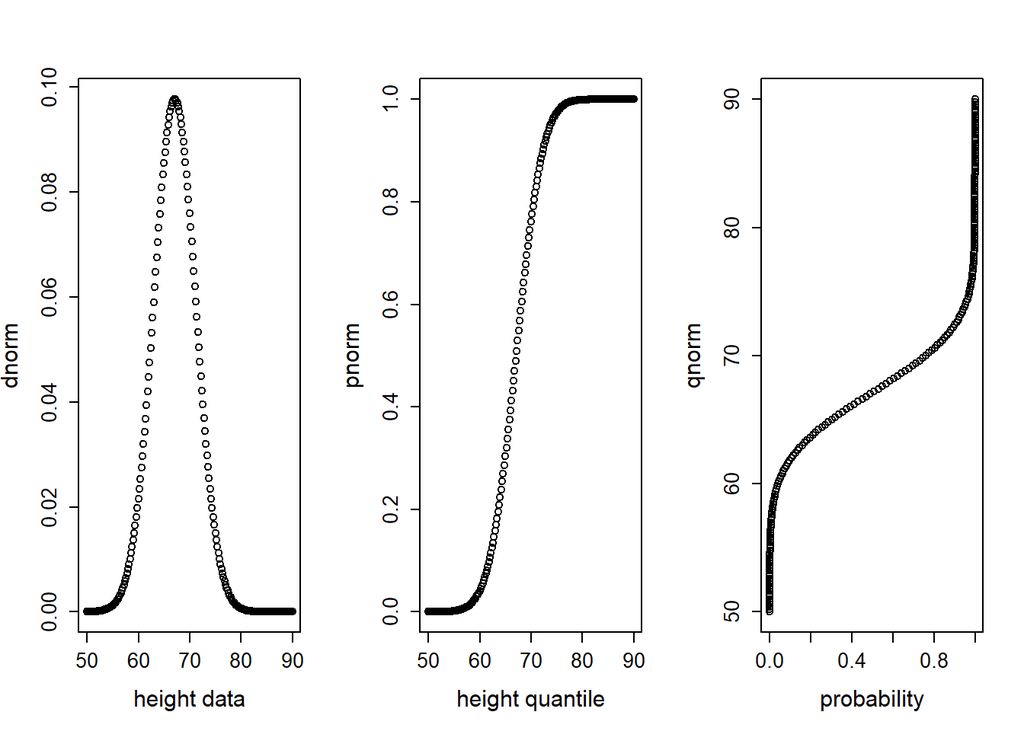

```r
heightvector <- seq(50,90,by=0.2)
## summary statistics from data
mu <- mean(heights$height) #67.10
sigma <- sd(heights$height) # 4.08

probability_density <- dnorm(heightvector, mean = mu, sd = sigma)
cumulative_probability_density <- pnorm(heightvector, mean = mu, sd = sigma)
inverse_cdf <- qnorm(cumulative_probability_density, mean = mu, sd= sigma)

heightsample <- rnorm(n=100, mean = mu, sd = sigma)


par(mfcol=c(1,3))
plot(heightvector, probability_density,xlab = "height data", ylab = "dnorm",cex.lab = 1.4, cex.axis=1.3)
plot(heightvector, cumulative_probability_density,xlab = "height quantile",ylab = "pnorm", cex.lab = 1.4,cex.axis=1.3)
plot(cumulative_probability_density,inverse_cdf, xlab = "probability",ylab = "qnorm", cex.lab = 1.4,cex.axis=1.3)
```

```r
par(mfcol= c(1,1))
```

### Sampling from a distribution

#### Model 1

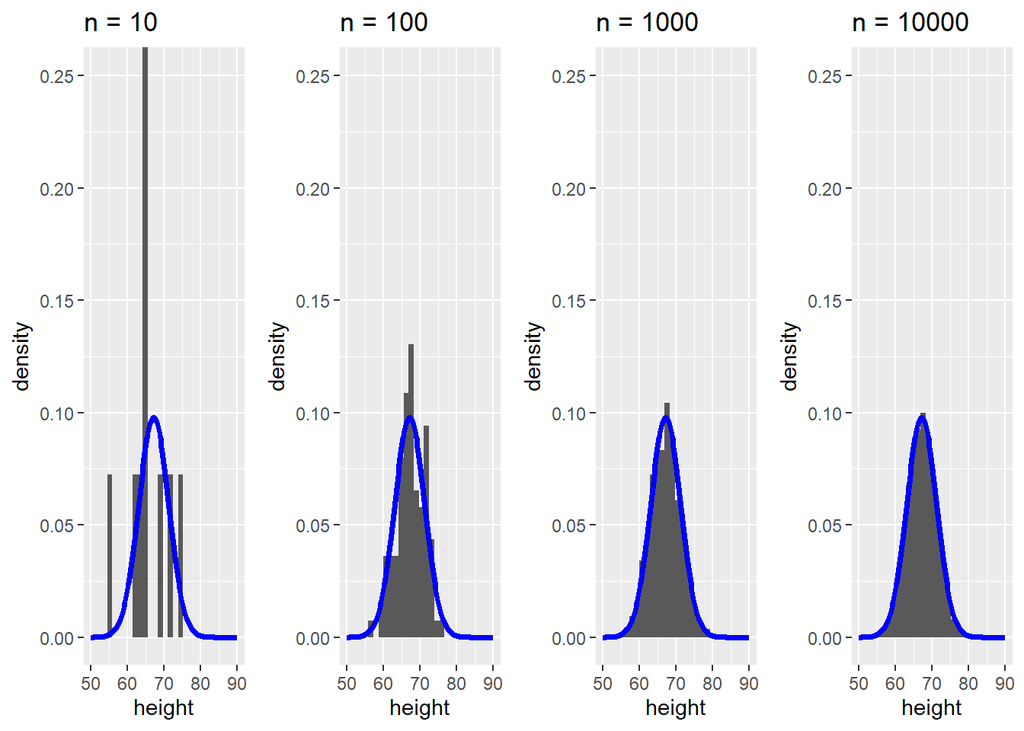

```r
## simple model
mu <- mean(heights$height) #67.10
sigma <- sd(heights$height) # 4.08

set.seed(20)# makes sure the random number generator produces the same results when we run it again.
# it doesn't matter what the number is in set.seed.

## plotting different sample sizes
samp10 <- rnorm(n = 10, mean = mu, sd = sigma)
samp100 <- rnorm(n = 100, mean = mu, sd = sigma)
samp1000 <- rnorm(n = 1000, mean = mu, sd = sigma)
samp10000 <- rnorm(n = 10000, mean = mu, sd = sigma)

## repeated sampling:
## ten samples of n = 10
samp2 <- matrix(data = NA, nrow = 10, ncol = 10)
for(i in 1:10){
  samp2[,i] <- rnorm(n = 10, mean = mu, sd = sigma)
}


m1line <- geom_line(aes(x = heightspan, y = model1), color = "blue", lwd=1.3)
ylims <-  coord_cartesian(ylim = c(0, 0.25),xlim = c(50,90))


p10 <- ggplot() + geom_histogram(aes(x= samp10, y = stat(density))) + m1line + ylims + labs(x = "height", title = "n = 10")
p100 <- ggplot() + geom_histogram(aes(x= samp100, y = stat(density))) + m1line + ylims+ labs(x = "height", title = "n = 100")
p1000 <- ggplot() + geom_histogram(aes(x= samp1000, y = stat(density))) + m1line + ylims + labs(x = "height", title = "n = 1000")

p10000 <- ggplot() + geom_histogram(aes(x= samp10000, y = stat(density))) + m1line + ylims+ labs(x = "height", title = "n = 10000")

cowplot::plot_grid(p10,p100,p1000,p10000,nrow = 1)
```

#### Model 2

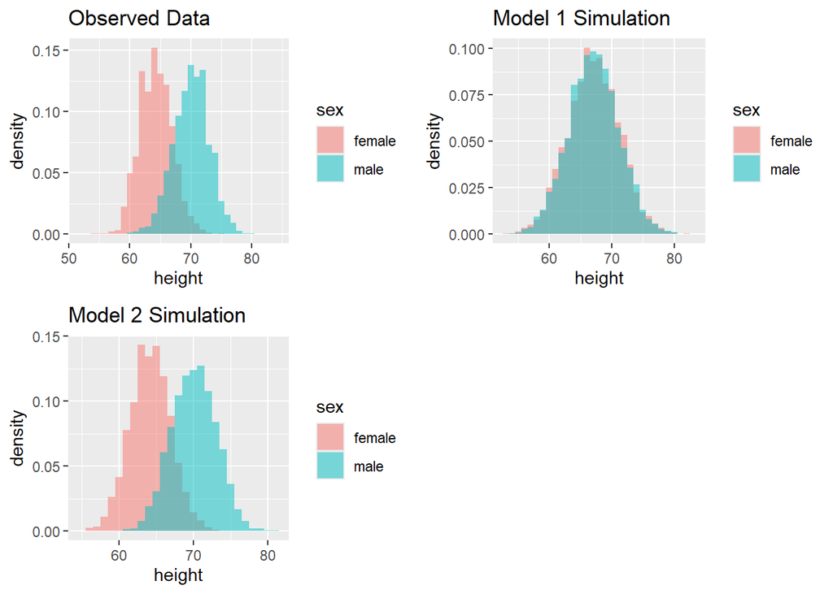

```r
## sample means and standard deviation for women and men:
mu = mean(heights$height)
sigma <- sd(heights$height)
mu_w <- m2pars$female$mean # 64.3
mu_m <- m2pars$male$mean # 70.1
sd_w <- m2pars$female$sd # 2.72
sd_m <- m2pars$male$sd # 2.99
## proportion of women in the sample
phi_w <- m2pars$female$phi # 0.51

N <- 10000 # sample size
W <- round(N * phi_w) # number of women, rounded to the nearest integer
M <- N - W # number of men

# make a column for women and men to add to the data:
gender <- c(rep("female",W),rep("male",M))

set.seed(10)
sampmodel1 <- rnorm(N, mean = mu, sd = sigma)
sampmodel2 <-c(rnorm(W, mean = mu_w, sd = sd_w),
           rnorm(M, mean = mu_m, sd = sd_m))
m1df <- data.frame(sex = factor(gender, levels = c("female","male")),
                   height = sampmodel1)
m2df <- data.frame(sex = factor(gender,levels = c("female","male")),
                   height = sampmodel2)

## make sure factor levels order the same way
heights$sex <- factor(heights$sex, levels = c("female","male"))

p0 <- ggplot(data = heights) +
  geom_histogram(aes(x = height, fill = sex,y = stat(density)),alpha = 0.5,binwidth = 1, position = "identity") +
  # alpha = 0.5 adds transparency to better see overlap
  # position = identity means that the bars show the number in each group, instead of the combined number
  labs(title = "Observed Data")
p1 <- ggplot(data = m1df) +
  geom_histogram(aes(x = height, y = stat(density),fill = sex),alpha = 0.5, binwidth = 1, position = "identity") +
  labs(x = "height", title = "Model 1 Simulation")
p2 <- ggplot(data = m2df) +
  geom_histogram(aes(x = height, y = stat(density),fill = sex),alpha = 0.5, binwidth = 1, position = "identity") +
  labs(x = "height", title = "Model 2 Simulation")

cowplot::plot_grid(p0, p1, p2)
```

# Exercises:

0. Adapt the code above to make a function that generates a sample for height data for men and women based on model 2 (gaussian mixture). The code chunk below has a template with steps

```r
sample_mw_height <- function( FILLIN ){## define the arguments for your function. We need the model parameters and the sample size.

  ## calculate the number of women and men based on N and phi_w

  ## Sample a vector of women heights
  ## Sample a vector of men heights

  ## Concatenate women and men heights into one vector

  ## Make a dataframe with sex and sampled heights

  outdf <- data.frame(FILL IN)

  ## return the dataframe
  return(outdf)
}
```

Using this function as a starting point, simulate the following scenarios. Use the code in the plot above as a starting point for visualizing your simulations.

1. The population represented in the 2012 heights survey is hit by a terrible disease that kills 10% of women and 30% of men. Simulate a new survey with 1000 people. Draw a histogram of your simulation alongside the original sample.
2. The survivors from the terrible disease experience strange changes in height. Now the average woman is twice as tall as the average man. Simulate a new survey with 10000 people. Draw a histogram of your simulation.
3. Thanks to the terrible disease, your capacity to conduct surveys is more limited than it was before. Using the population from question 2, simulate a survey of 100, 1000, and 10000 people. Repeat each survey 3 times. How does the sample size affect the consistency of your results? Draw histograms of all your simulations.